# Credit Card Client Segmentation

## Business Context and Problem

A Colombian bank has spending data for more than 47,000 credit cardholders, but has no way to group these clients according to how they use their card. Without this segmentation, promotions are designed generically, without taking advantage of consumption, spending and behavior patterns.

**Goal:** segment clients using K-Means clustering based on their transaction behavior, to enable more targeted, data-driven promotional strategies.

```python
import pandas as pd
df = pd.read_excel('/content/drive/MyDrive/Colab Notebooks/Portfolio/Python_SQL/infoclientebanca_en.xlsx')
df.head()
```

|  | CLIENT | client_group | number_of_transactions | avg_transaction_amount | min_transaction_amount | max_transaction_amount | transaction_std_dev | pct_visa_domestic | pct_visa_international | pct_mastercard_domestic | ... | pct_afternoon | pct_evening | pct_sunday | pct_monday | pct_tuesday | pct_wednesday | pct_thursday | pct_friday | pct_saturday | most_frequent_merchant_category |
| --- | --- | --- | --- | --- | --- | --- | --- | --- | --- | --- | --- | --- | --- | --- | --- | --- | --- | --- | --- | --- | --- |
| 0 | 1 | A | 1 | 459930.3 | 459930.3 | 459930.3 | 0.00 | 0.0 | 1.0 | 0.0 | ... | 0.0 | 1.0 | 0.0 | 0.000000 | 1.0 | 0.0 | 0.000000 | 0.0 | 0.0 | CLINICS - HOSPITALS |
| 1 | 2 | A | 3 | 582666.7 | 350000.0 | 699000.0 | 201495.23 | 1.0 | 0.0 | 0.0 | ... | 1.0 | 0.0 | 0.0 | 0.666667 | 0.0 | 0.0 | 0.333333 | 0.0 | 0.0 | DIRECT MARKETING - TELEMARKETING / DIRECTV |
| 2 | 3 | A | 3 | 616547.0 | 616547.0 | 616547.0 | 0.00 | 1.0 | 0.0 | 0.0 | ... | 0.0 | 0.0 | 0.0 | 0.000000 | 0.0 | 1.0 | 0.000000 | 0.0 | 0.0 | PHARMACIES, DRUGSTORES, HEALTH FOOD STORES |
| 3 | 4 | A | 10 | 144467.1 | 20000.0 | 328444.0 | 116685.81 | 0.0 | 0.0 | 1.0 | ... | 0.6 | 0.0 | 0.0 | 0.600000 | 0.2 | 0.0 | 0.100000 | 0.0 | 0.1 | DEPARTMENT STORE WITH SUPERMARKET |
| 4 | 5 | A | 1 | 321764.0 | 321764.0 | 321764.0 | 0.00 | 1.0 | 0.0 | 0.0 | ... | 1.0 | 0.0 | 1.0 | 0.000000 | 0.0 | 0.0 | 0.000000 | 0.0 | 0.0 | DEPARTMENT STORE WITH SUPERMARKET |

5 rows × 26 columns

```python
#Remove the variables not required for clustering; most_frequent_merchant_category will be transformed separately.
df_1 = df.drop(['CLIENT','client_group','most_frequent_merchant_category'], axis=1)
df_1.head()
```

|  | number_of_transactions | avg_transaction_amount | min_transaction_amount | max_transaction_amount | transaction_std_dev | pct_visa_domestic | pct_visa_international | pct_mastercard_domestic | pct_mastercard_international | pct_other_card_domestic | ... | pct_morning | pct_afternoon | pct_evening | pct_sunday | pct_monday | pct_tuesday | pct_wednesday | pct_thursday | pct_friday | pct_saturday |
| --- | --- | --- | --- | --- | --- | --- | --- | --- | --- | --- | --- | --- | --- | --- | --- | --- | --- | --- | --- | --- | --- |
| 0 | 1 | 459930.3 | 459930.3 | 459930.3 | 0.00 | 0.0 | 1.0 | 0.0 | 0.0 | 0.0 | ... | 0.0 | 0.0 | 1.0 | 0.0 | 0.000000 | 1.0 | 0.0 | 0.000000 | 0.0 | 0.0 |
| 1 | 3 | 582666.7 | 350000.0 | 699000.0 | 201495.23 | 1.0 | 0.0 | 0.0 | 0.0 | 0.0 | ... | 0.0 | 1.0 | 0.0 | 0.0 | 0.666667 | 0.0 | 0.0 | 0.333333 | 0.0 | 0.0 |
| 2 | 3 | 616547.0 | 616547.0 | 616547.0 | 0.00 | 1.0 | 0.0 | 0.0 | 0.0 | 0.0 | ... | 1.0 | 0.0 | 0.0 | 0.0 | 0.000000 | 0.0 | 1.0 | 0.000000 | 0.0 | 0.0 |
| 3 | 10 | 144467.1 | 20000.0 | 328444.0 | 116685.81 | 0.0 | 0.0 | 1.0 | 0.0 | 0.0 | ... | 0.4 | 0.6 | 0.0 | 0.0 | 0.600000 | 0.2 | 0.0 | 0.100000 | 0.0 | 0.1 |
| 4 | 1 | 321764.0 | 321764.0 | 321764.0 | 0.00 | 1.0 | 0.0 | 0.0 | 0.0 | 0.0 | ... | 0.0 | 1.0 | 0.0 | 1.0 | 0.000000 | 0.0 | 0.0 | 0.000000 | 0.0 | 0.0 |

5 rows × 23 columns

```python
#Transform 'most_frequent_merchant_category' from categorical to numeric using dummy variables (kept for reference; not used in the clustering variables below).
df_2 = pd.get_dummies(df['most_frequent_merchant_category']).astype(int)
df_2.head()
```

|  | ADVERTISING, MEDIA AND GRAPHIC ARTS SERVICES | AGRICULTURAL EQUIPMENT, SUPPLIES AND SERVICES STORES | AIRLINES | AMBULANCE SERVICES | APPLIANCE AND GAS APPLIANCE STORES | ART GALLERIES - FRAME SHOPS | AUTO PARTS AND ACCESSORIES | AUTO REPAIR, BODYWORK, PAINT AND TOWING SERVICES | AUTO SERVICE CENTERS AND TIRE SHOPS | AVIATION COMPANIES | ... | TICKET AGENCIES (Theater Productions) except movies | TOBACCO AND LIQUOR STORES | TRAVEL AGENCIES AND TOUR OPERATORS | UNNAMED | UTILITIES | VARIETY, HOUSEWARES AND GIFT STORES / GENERAL STORES | VEHICLE RENTAL COMPANIES | VETERINARY CLINICS AND SERVICES | VIDEO RENTAL STORES | WATCH, JEWELRY AND SILVERWARE STORES |
| --- | --- | --- | --- | --- | --- | --- | --- | --- | --- | --- | --- | --- | --- | --- | --- | --- | --- | --- | --- | --- | --- |
| 0 | 0 | 0 | 0 | 0 | 0 | 0 | 0 | 0 | 0 | 0 | ... | 0 | 0 | 0 | 0 | 0 | 0 | 0 | 0 | 0 | 0 |
| 1 | 0 | 0 | 0 | 0 | 0 | 0 | 0 | 0 | 0 | 0 | ... | 0 | 0 | 0 | 0 | 0 | 0 | 0 | 0 | 0 | 0 |
| 2 | 0 | 0 | 0 | 0 | 0 | 0 | 0 | 0 | 0 | 0 | ... | 0 | 0 | 0 | 0 | 0 | 0 | 0 | 0 | 0 | 0 |
| 3 | 0 | 0 | 0 | 0 | 0 | 0 | 0 | 0 | 0 | 0 | ... | 0 | 0 | 0 | 0 | 0 | 0 | 0 | 0 | 0 | 0 |
| 4 | 0 | 0 | 0 | 0 | 0 | 0 | 0 | 0 | 0 | 0 | ... | 0 | 0 | 0 | 0 | 0 | 0 | 0 | 0 | 0 | 0 |

5 rows × 109 columns

```python
#Combine both dataframes. df_cluster keeps all behavioral variables and will be used for the cluster profiling later.
df_cluster = pd.concat([df_1, df_2], axis=1)
df_cluster.head()
```

|  | number_of_transactions | avg_transaction_amount | min_transaction_amount | max_transaction_amount | transaction_std_dev | pct_visa_domestic | pct_visa_international | pct_mastercard_domestic | pct_mastercard_international | pct_other_card_domestic | ... | TICKET AGENCIES (Theater Productions) except movies | TOBACCO AND LIQUOR STORES | TRAVEL AGENCIES AND TOUR OPERATORS | UNNAMED | UTILITIES | VARIETY, HOUSEWARES AND GIFT STORES / GENERAL STORES | VEHICLE RENTAL COMPANIES | VETERINARY CLINICS AND SERVICES | VIDEO RENTAL STORES | WATCH, JEWELRY AND SILVERWARE STORES |
| --- | --- | --- | --- | --- | --- | --- | --- | --- | --- | --- | --- | --- | --- | --- | --- | --- | --- | --- | --- | --- | --- |
| 0 | 1 | 459930.3 | 459930.3 | 459930.3 | 0.00 | 0.0 | 1.0 | 0.0 | 0.0 | 0.0 | ... | 0 | 0 | 0 | 0 | 0 | 0 | 0 | 0 | 0 | 0 |
| 1 | 3 | 582666.7 | 350000.0 | 699000.0 | 201495.23 | 1.0 | 0.0 | 0.0 | 0.0 | 0.0 | ... | 0 | 0 | 0 | 0 | 0 | 0 | 0 | 0 | 0 | 0 |
| 2 | 3 | 616547.0 | 616547.0 | 616547.0 | 0.00 | 1.0 | 0.0 | 0.0 | 0.0 | 0.0 | ... | 0 | 0 | 0 | 0 | 0 | 0 | 0 | 0 | 0 | 0 |
| 3 | 10 | 144467.1 | 20000.0 | 328444.0 | 116685.81 | 0.0 | 0.0 | 1.0 | 0.0 | 0.0 | ... | 0 | 0 | 0 | 0 | 0 | 0 | 0 | 0 | 0 | 0 |
| 4 | 1 | 321764.0 | 321764.0 | 321764.0 | 0.00 | 1.0 | 0.0 | 0.0 | 0.0 | 0.0 | ... | 0 | 0 | 0 | 0 | 0 | 0 | 0 | 0 | 0 | 0 |

5 rows × 132 columns

```python
#Build the clustering input: after testing, using ALL variables together produced an elbow curve with no visible bend
#(too many correlated/redundant features flatten the inertia curve). Reducing to the 2 variables that best differentiate
#spending behavior -- number of transactions and average transaction amount -- and log-transforming them (both are highly
#skewed: most clients have very few transactions, a handful have many) produces a much clearer elbow.
import numpy as np
from sklearn.preprocessing import StandardScaler

cluster_vars = df_cluster[['number_of_transactions', 'avg_transaction_amount']].copy()
cluster_vars['number_of_transactions'] = np.log1p(cluster_vars['number_of_transactions'])
cluster_vars['avg_transaction_amount'] = np.log1p(cluster_vars['avg_transaction_amount'])

scaler = StandardScaler()
array_norm = scaler.fit_transform(cluster_vars)
```

### Elbow Method to determine the optimal number of clusters

```python
#Evaluate from 1 to 6 clusters.
from sklearn.cluster import KMeans
inercias = []
for k in range(1, 7):
  kmeans = KMeans(n_clusters=k, random_state=42, n_init=10)
  kmeans.fit(array_norm)
  inercias.append(kmeans.inertia_)
```

```python
#Chart library
import matplotlib.pyplot as plt
# Color palette
color_principal = '#f4df52'
colores_clusters = ['#f4df52', '#6940c9', '#D9BC07', '#9b7cff']
```

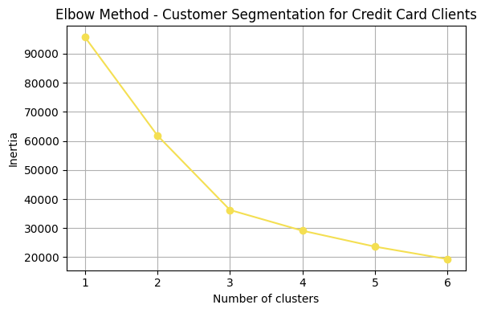

```python
#Plot inertia to identify the optimal number of clusters.
plt.figure(figsize=(6, 4), facecolor='white')
plt.plot(range(1, 7), inercias, marker='o', color=color_principal)
plt.xlabel('Number of clusters')
plt.ylabel('Inertia')
plt.title('Elbow Method - Customer Segmentation for Credit Card Clients')
plt.grid(True)
plt.gca().set_facecolor('white')
plt.tight_layout()
plt.show()
```

**Conclusion:** 3 clusters are selected as the optimal number, since the inertia reduction becomes much less significant beyond this point, and 3 clusters provide a clear, manageable segmentation of clients based on transaction frequency and spending level.

```python
#Train the final model with 3 clusters.
Kmeans_final = KMeans(n_clusters=3, random_state=42, n_init=10)
Kmeans_final.fit(array_norm)
```

```
KMeans(n_clusters=3, n_init=10, random_state=42)
```

```python
#Add a column indicating which cluster each client belongs to.
df_cluster['cluster'] = Kmeans_final.labels_
df_cluster.head()
```

|  | number_of_transactions | avg_transaction_amount | min_transaction_amount | max_transaction_amount | transaction_std_dev | pct_visa_domestic | pct_visa_international | pct_mastercard_domestic | pct_mastercard_international | pct_other_card_domestic | ... | TOBACCO AND LIQUOR STORES | TRAVEL AGENCIES AND TOUR OPERATORS | UNNAMED | UTILITIES | VARIETY, HOUSEWARES AND GIFT STORES / GENERAL STORES | VEHICLE RENTAL COMPANIES | VETERINARY CLINICS AND SERVICES | VIDEO RENTAL STORES | WATCH, JEWELRY AND SILVERWARE STORES | cluster |
| --- | --- | --- | --- | --- | --- | --- | --- | --- | --- | --- | --- | --- | --- | --- | --- | --- | --- | --- | --- | --- | --- |
| 0 | 1 | 459930.3 | 459930.3 | 459930.3 | 0.00 | 0.0 | 1.0 | 0.0 | 0.0 | 0.0 | ... | 0 | 0 | 0 | 0 | 0 | 0 | 0 | 0 | 0 | 1 |
| 1 | 3 | 582666.7 | 350000.0 | 699000.0 | 201495.23 | 1.0 | 0.0 | 0.0 | 0.0 | 0.0 | ... | 0 | 0 | 0 | 0 | 0 | 0 | 0 | 0 | 0 | 1 |
| 2 | 3 | 616547.0 | 616547.0 | 616547.0 | 0.00 | 1.0 | 0.0 | 0.0 | 0.0 | 0.0 | ... | 0 | 0 | 0 | 0 | 0 | 0 | 0 | 0 | 0 | 1 |
| 3 | 10 | 144467.1 | 20000.0 | 328444.0 | 116685.81 | 0.0 | 0.0 | 1.0 | 0.0 | 0.0 | ... | 0 | 0 | 0 | 0 | 0 | 0 | 0 | 0 | 0 | 2 |
| 4 | 1 | 321764.0 | 321764.0 | 321764.0 | 0.00 | 1.0 | 0.0 | 0.0 | 0.0 | 0.0 | ... | 0 | 0 | 0 | 0 | 0 | 0 | 0 | 0 | 0 | 1 |

5 rows × 133 columns

```python
#Compute the average of each variable per cluster.
df_cluster.groupby('cluster').mean(numeric_only=True).round(2)
```

| cluster | number_of_transactions | avg_transaction_amount | min_transaction_amount | max_transaction_amount | transaction_std_dev | pct_visa_domestic | pct_visa_international | pct_mastercard_domestic | pct_mastercard_international | pct_other_card_domestic | ... | TICKET AGENCIES (Theater Productions) except movies | TOBACCO AND LIQUOR STORES | TRAVEL AGENCIES AND TOUR OPERATORS | UNNAMED | UTILITIES | VARIETY, HOUSEWARES AND GIFT STORES / GENERAL STORES | VEHICLE RENTAL COMPANIES | VETERINARY CLINICS AND SERVICES | VIDEO RENTAL STORES | WATCH, JEWELRY AND SILVERWARE STORES |
| --- | --- | --- | --- | --- | --- | --- | --- | --- | --- | --- | --- | --- | --- | --- | --- | --- | --- | --- | --- | --- | --- |
| 0 | 2.04 | 98579.66 | 76835.14 | 124724.74 | 26768.99 | 0.39 | 0.02 | 0.57 | 0.01 | 0.01 | ... | 0.0 | 0.0 | 0.00 | 0.07 | 0.0 | 0.02 | 0.0 | 0.0 | 0.0 | 0.0 |
| 1 | 2.23 | 846525.51 | 634758.75 | 1126643.43 | 252983.19 | 0.40 | 0.05 | 0.49 | 0.04 | 0.01 | ... | 0.0 | 0.0 | 0.03 | 0.11 | 0.0 | 0.01 | 0.0 | 0.0 | 0.0 | 0.0 |
| 2 | 14.32 | 204891.79 | 43151.95 | 639336.34 | 184833.86 | 0.32 | 0.05 | 0.57 | 0.04 | 0.02 | ... | 0.0 | 0.0 | 0.01 | 0.01 | 0.0 | 0.02 | 0.0 | 0.0 | 0.0 | 0.0 |

3 rows × 132 columns

### Part 2: Cluster Analysis Using SQL

```python
#Create another dataframe where 'most_frequent_merchant_category' has not been transformed or removed.
#Drop the columns not needed: 'CLIENT' and 'client_group'.
df_3 = df.drop(['CLIENT','client_group'], axis=1)
df_3.head()
```

|  | number_of_transactions | avg_transaction_amount | min_transaction_amount | max_transaction_amount | transaction_std_dev | pct_visa_domestic | pct_visa_international | pct_mastercard_domestic | pct_mastercard_international | pct_other_card_domestic | ... | pct_afternoon | pct_evening | pct_sunday | pct_monday | pct_tuesday | pct_wednesday | pct_thursday | pct_friday | pct_saturday | most_frequent_merchant_category |
| --- | --- | --- | --- | --- | --- | --- | --- | --- | --- | --- | --- | --- | --- | --- | --- | --- | --- | --- | --- | --- | --- |
| 0 | 1 | 459930.3 | 459930.3 | 459930.3 | 0.00 | 0.0 | 1.0 | 0.0 | 0.0 | 0.0 | ... | 0.0 | 1.0 | 0.0 | 0.000000 | 1.0 | 0.0 | 0.000000 | 0.0 | 0.0 | CLINICS - HOSPITALS |
| 1 | 3 | 582666.7 | 350000.0 | 699000.0 | 201495.23 | 1.0 | 0.0 | 0.0 | 0.0 | 0.0 | ... | 1.0 | 0.0 | 0.0 | 0.666667 | 0.0 | 0.0 | 0.333333 | 0.0 | 0.0 | DIRECT MARKETING - TELEMARKETING / DIRECTV |
| 2 | 3 | 616547.0 | 616547.0 | 616547.0 | 0.00 | 1.0 | 0.0 | 0.0 | 0.0 | 0.0 | ... | 0.0 | 0.0 | 0.0 | 0.000000 | 0.0 | 1.0 | 0.000000 | 0.0 | 0.0 | PHARMACIES, DRUGSTORES, HEALTH FOOD STORES |
| 3 | 10 | 144467.1 | 20000.0 | 328444.0 | 116685.81 | 0.0 | 0.0 | 1.0 | 0.0 | 0.0 | ... | 0.6 | 0.0 | 0.0 | 0.600000 | 0.2 | 0.0 | 0.100000 | 0.0 | 0.1 | DEPARTMENT STORE WITH SUPERMARKET |
| 4 | 1 | 321764.0 | 321764.0 | 321764.0 | 0.00 | 1.0 | 0.0 | 0.0 | 0.0 | 0.0 | ... | 1.0 | 0.0 | 1.0 | 0.000000 | 0.0 | 0.0 | 0.000000 | 0.0 | 0.0 | DEPARTMENT STORE WITH SUPERMARKET |

5 rows × 24 columns

```python
#Add a column indicating which cluster each client belongs to.
df_3['cluster'] = Kmeans_final.labels_
df_3.head()
```

|  | number_of_transactions | avg_transaction_amount | min_transaction_amount | max_transaction_amount | transaction_std_dev | pct_visa_domestic | pct_visa_international | pct_mastercard_domestic | pct_mastercard_international | pct_other_card_domestic | ... | pct_evening | pct_sunday | pct_monday | pct_tuesday | pct_wednesday | pct_thursday | pct_friday | pct_saturday | most_frequent_merchant_category | cluster |
| --- | --- | --- | --- | --- | --- | --- | --- | --- | --- | --- | --- | --- | --- | --- | --- | --- | --- | --- | --- | --- | --- |
| 0 | 1 | 459930.3 | 459930.3 | 459930.3 | 0.00 | 0.0 | 1.0 | 0.0 | 0.0 | 0.0 | ... | 1.0 | 0.0 | 0.000000 | 1.0 | 0.0 | 0.000000 | 0.0 | 0.0 | CLINICS - HOSPITALS | 1 |
| 1 | 3 | 582666.7 | 350000.0 | 699000.0 | 201495.23 | 1.0 | 0.0 | 0.0 | 0.0 | 0.0 | ... | 0.0 | 0.0 | 0.666667 | 0.0 | 0.0 | 0.333333 | 0.0 | 0.0 | DIRECT MARKETING - TELEMARKETING / DIRECTV | 1 |
| 2 | 3 | 616547.0 | 616547.0 | 616547.0 | 0.00 | 1.0 | 0.0 | 0.0 | 0.0 | 0.0 | ... | 0.0 | 0.0 | 0.000000 | 0.0 | 1.0 | 0.000000 | 0.0 | 0.0 | PHARMACIES, DRUGSTORES, HEALTH FOOD STORES | 1 |
| 3 | 10 | 144467.1 | 20000.0 | 328444.0 | 116685.81 | 0.0 | 0.0 | 1.0 | 0.0 | 0.0 | ... | 0.0 | 0.0 | 0.600000 | 0.2 | 0.0 | 0.100000 | 0.0 | 0.1 | DEPARTMENT STORE WITH SUPERMARKET | 2 |
| 4 | 1 | 321764.0 | 321764.0 | 321764.0 | 0.00 | 1.0 | 0.0 | 0.0 | 0.0 | 0.0 | ... | 0.0 | 1.0 | 0.000000 | 0.0 | 0.0 | 0.000000 | 0.0 | 0.0 | DEPARTMENT STORE WITH SUPERMARKET | 1 |

5 rows × 25 columns

```python
#Create the SQLite database and store the client data.
import sqlite3

conn = sqlite3.connect('banco.db')
df_3.to_sql('clientes', conn, if_exists='replace', index=False)
```

```
47871
```

```python
#Query 1: identify the most_frequent_merchant_category of each cluster and the number of clients in that group.
query = """
SELECT cluster, most_frequent_merchant_category, total
FROM (
    SELECT cluster, most_frequent_merchant_category, COUNT(*) as total,
           ROW_NUMBER() OVER (PARTITION BY cluster ORDER BY COUNT(*) DESC) as rn
    FROM clientes
    GROUP BY cluster, most_frequent_merchant_category
)
WHERE rn = 1
"""
#Create the 'resultado' dataframe to store the query results.
resultado = pd.read_sql_query(query, conn)
resultado.head()
```

|  | cluster | most_frequent_merchant_category | total |
| --- | --- | --- | --- |
| 0 | 0 | SUPERMARKETS / EXPRESS STORES | 4088 |
| 1 | 1 | SUPERMARKETS / EXPRESS STORES | 2220 |
| 2 | 2 | SUPERMARKETS / EXPRESS STORES | 2896 |

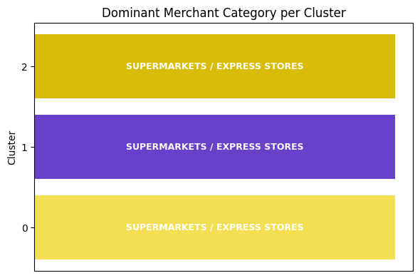

```python
plt.figure(figsize=(6, 4), facecolor='white')
plt.barh(resultado['cluster'].astype(str), [1]*len(resultado), color=colores_clusters)
plt.ylabel('Cluster')
plt.xticks([])
plt.title('Dominant Merchant Category per Cluster')

for i, sitio in enumerate(resultado['most_frequent_merchant_category']):
    plt.text(0.5, i, sitio, ha='center', va='center', color='white',
              fontweight='bold', fontsize=9)

plt.gca().set_facecolor('white')
plt.tight_layout()
plt.show()
```

```python
#Query 2: compute the number of clients and their share within each cluster.
query = """
SELECT cluster, COUNT(cluster) as num_clientes,
ROUND((COUNT(cluster)*100.0/(SELECT COUNT(cluster) FROM clientes)),2) as porcentaje
FROM clientes
GROUP BY cluster
"""
resultado2 = pd.read_sql_query(query, conn)
resultado2['porcentaje'] = resultado2['porcentaje'].astype(str) + '%'
resultado2.head()
```

|  | cluster | num_clientes | porcentaje |
| --- | --- | --- | --- |
| 0 | 0 | 20436 | 42.69% |
| 1 | 1 | 15824 | 33.06% |
| 2 | 2 | 11611 | 24.25% |

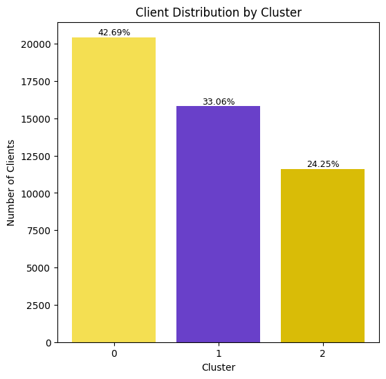

```python
plt.figure(figsize=(6, 6))
barras = plt.bar(
    resultado2['cluster'].astype(str),
    resultado2['num_clientes'],
    color=colores_clusters,
)
plt.xlabel('Cluster')
plt.ylabel('Number of Clients')
plt.title('Client Distribution by Cluster')
plt.grid(False)
for barra, porcentaje in zip(barras, resultado2['porcentaje']):
  plt.text(
      barra.get_x() + barra.get_width() / 2,
      barra.get_height(),
      porcentaje,
      ha='center',
      va='bottom',
      fontsize=9,
  )
plt.show()
```

**Conclusion:** the 3 clusters are well balanced, each representing a distinct spending behavior profile based on transaction frequency and average transaction size.

```python
#Compute the average transaction amount for each cluster.
promedio_transaccion = df_cluster.groupby('cluster')['avg_transaction_amount'].mean()
promedio_transaccion
```

```
cluster
0     98579.663110
1    846525.510553
2    204891.792495
Name: avg_transaction_amount, dtype: float64
```

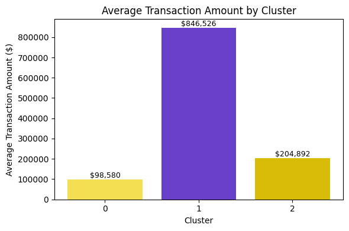

```python
plt.figure(figsize=(6, 4), facecolor='white')
barras = plt.bar(promedio_transaccion.index.astype(str), promedio_transaccion.values, color=colores_clusters)
plt.xlabel('Cluster')
plt.ylabel('Average Transaction Amount ($)')
plt.title('Average Transaction Amount by Cluster')
plt.grid(False)

for barra, valor in zip(barras, promedio_transaccion.values):
    plt.text(barra.get_x() + barra.get_width()/2, barra.get_height(),
              f'${valor:,.0f}', ha='center', va='bottom', fontsize=9)
plt.gca().set_facecolor('white')
plt.tight_layout()
plt.show()
```

```python
#Query 3: average share of transactions made with each card franchise (Visa, Mastercard, other) per cluster.
query = """
SELECT cluster,
AVG(pct_visa_domestic + pct_visa_international) as promedio_visa,
AVG(pct_mastercard_domestic + pct_mastercard_international) as promedio_mastercard,
AVG(pct_other_card_domestic + pct_other_card_international) as promedio_otrafranquicia
FROM clientes
GROUP BY cluster
"""
resultado3 = pd.read_sql_query(query, conn)
resultado3.head()
```

|  | cluster | promedio_visa | promedio_mastercard | promedio_otrafranquicia |
| --- | --- | --- | --- | --- |
| 0 | 0 | 0.406616 | 0.576361 | 0.017023 |
| 1 | 1 | 0.449276 | 0.524216 | 0.026508 |
| 2 | 2 | 0.367931 | 0.604177 | 0.027893 |

```python
#Identify the most used franchise per cluster.
resultado3['tarjeta_mas_usada'] = resultado3[['promedio_visa', 'promedio_mastercard', 'promedio_otrafranquicia']].idxmax(axis=1)
resultado3['promedio_maximo'] = resultado3[['promedio_visa', 'promedio_mastercard', 'promedio_otrafranquicia']].max(axis=1)
resultado3_final = resultado3[['cluster', 'tarjeta_mas_usada', 'promedio_maximo']].merge(
    resultado2[['cluster', 'num_clientes']], on='cluster', how='left'
)
resultado3_final.head()
```

|  | cluster | tarjeta_mas_usada | promedio_maximo | num_clientes |
| --- | --- | --- | --- | --- |
| 0 | 0 | promedio_mastercard | 0.576361 | 20436 |
| 1 | 1 | promedio_mastercard | 0.524216 | 15824 |
| 2 | 2 | promedio_mastercard | 0.604177 | 11611 |

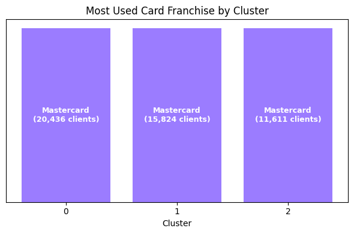

```python
plt.figure(figsize=(6, 4), facecolor='white')
colores_franquicia = ['#9b7cff', '#9b7cff', '#9b7cff', '#f4df52']
plt.bar(resultado3_final['cluster'].astype(str), [1]*len(resultado3_final), color=colores_franquicia[:len(resultado3_final)])
plt.xlabel('Cluster')
plt.yticks([])
plt.title('Most Used Card Franchise by Cluster')

for i, (tarjeta, n_clientes) in enumerate(zip(resultado3_final['tarjeta_mas_usada'], resultado3_final['num_clientes'])):
    label = tarjeta.replace('promedio_', '').capitalize()
    plt.text(i, 0.5, f'{label}\n({n_clientes:,} clients)',
             ha='center', va='center', color='white', fontweight='bold', fontsize=9)
plt.gca().set_facecolor('white')
plt.tight_layout()
plt.show()
```

```python
#Compute the average domestic vs. international spending share per cluster.
nacional_internacional = df_cluster.groupby('cluster')[['pct_domestic_total', 'pct_international_total']].mean()
nacional_internacional
```

| cluster | pct_domestic_total | pct_international_total |
| --- | --- | --- |
| 0 | 0.969456 | 0.030544 |
| 1 | 0.896517 | 0.103483 |
| 2 | 0.898277 | 0.101723 |

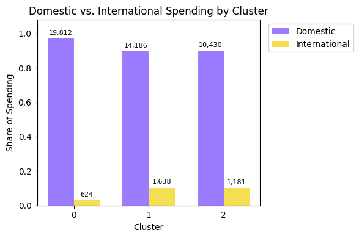

```python
import numpy as np
clusters = nacional_internacional.index.astype(str)
nac = nacional_internacional['pct_domestic_total']
inter = nacional_internacional['pct_international_total']
n_clientes_por_cluster = resultado2.set_index('cluster')['num_clientes']
x = np.arange(len(clusters))
width = 0.35
fig, ax = plt.subplots(figsize=(6, 4), facecolor='white')
rects1 = ax.bar(x - width/2, nac, width, label='Domestic', color='#9b7cff')
rects2 = ax.bar(x + width/2, inter, width, label='International', color='#f4df52')
for i, c in enumerate(nacional_internacional.index):
    n_cluster = n_clientes_por_cluster.loc[c]
    n_nac = round(n_cluster * nac.loc[c])
    n_inter = round(n_cluster * inter.loc[c])
    ax.text(x[i] - width/2, nac.loc[c] + 0.015, f'{n_nac:,}', ha='center', va='bottom', fontsize=8)
    ax.text(x[i] + width/2, inter.loc[c] + 0.015, f'{n_inter:,}', ha='center', va='bottom', fontsize=8)

ax.set_xlabel('Cluster')
ax.set_ylabel('Share of Spending')
ax.set_title('Domestic vs. International Spending by Cluster')
ax.set_xticks(x)
ax.set_xticklabels(clusters)
ax.set_ylim(0, 1.08)
ax.legend(bbox_to_anchor=(1.02, 1), loc='upper left')
ax.set_facecolor('white')
plt.tight_layout()
plt.show()
```

```python
#Compute the average spending share across different times of day per cluster.
horario = df_cluster.groupby('cluster')[['pct_morning', 'pct_afternoon', 'pct_evening']].mean()
```

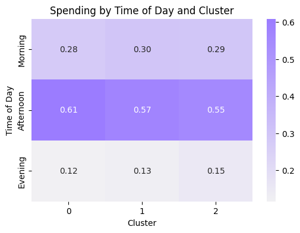

```python
import seaborn as sns
horario_display = horario.rename(columns={'pct_morning': 'Morning', 'pct_afternoon': 'Afternoon', 'pct_evening': 'Evening'})
cmap_morado = sns.light_palette("#9b7cff", as_cmap=True)
plt.figure(figsize=(6, 4))
sns.heatmap(horario_display.T, annot=True, fmt='.2f', cmap=cmap_morado)
plt.xlabel('Cluster')
plt.ylabel('Time of Day')
plt.title('Spending by Time of Day and Cluster')
plt.show()
```

**Observation:** the afternoon is the dominant time slot across all three clusters (55-61% of spending), followed by mornings (~28-30%) and evenings (12-15%). The pattern is consistent across clusters, meaning time of day is not a strong differentiator between these customer segments.

```python
#Compute the average spending share across days of the week per cluster.
dias_semana = df_cluster.groupby('cluster')[['pct_sunday', 'pct_monday', 'pct_tuesday', 'pct_wednesday',
                                                'pct_thursday', 'pct_friday', 'pct_saturday']].mean()
```

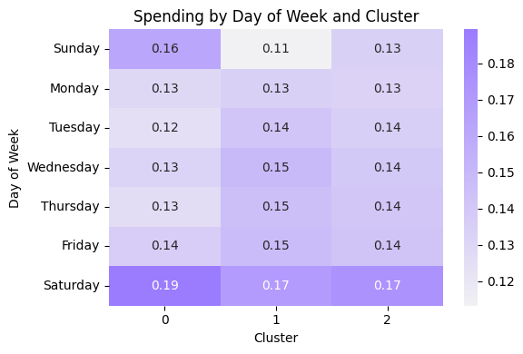

```python
dias_semana_display = dias_semana.rename(columns={
    'pct_sunday': 'Sunday', 'pct_monday': 'Monday', 'pct_tuesday': 'Tuesday',
    'pct_wednesday': 'Wednesday', 'pct_thursday': 'Thursday', 'pct_friday': 'Friday', 'pct_saturday': 'Saturday'
})

cmap_morado = sns.light_palette("#9b7cff", as_cmap=True)
plt.figure(figsize=(6, 4), facecolor='white')
sns.heatmap(dias_semana_display.T, annot=True, fmt='.2f', cmap=cmap_morado)
plt.xlabel('Cluster')
plt.ylabel('Day of Week')
plt.title('Spending by Day of Week and Cluster')
plt.tight_layout()
plt.show()
```

**Observation:** Saturday is the peak spending day across all three clusters (17-19% of weekly spending), with the rest of the week showing a fairly even distribution. As with time of day, the weekly pattern is similar across clusters and does not by itself distinguish one segment from another.

## Final Analysis

> **Cluster 0** is the largest group, with **42.7% of clients** (20,436 clients). It is defined by low transaction frequency (around 2 transactions) and the lowest average transaction amount ($98,580), making it the bank's "occasional, low-spend" segment. Mastercard is the preferred card (57.6% of spending) for domestic purchases (96.9% of spending stays domestic, the highest share of the three clusters), and "Supermarkets / Express Stores" is the dominant merchant category.

> **Cluster 1** represents **33.1% of clients** (15,824 clients). Like Cluster 0, these clients transact infrequently (around 2 transactions), but their average transaction amount is by far the highest of the three clusters at **$846,526** — nearly 9 times higher than Cluster 0. This is the bank's "occasional, high-value" segment: clients who make large purchases when they do use the card. Mastercard is again the leading franchise (52.4%), and this cluster has the highest share of international spending (10.3%) among the three.

> **Cluster 2** is the smallest group at **24.2% of clients** (11,611 clients), but it stands out for transaction frequency: these clients average **14.3 transactions**, roughly 6-7 times more often than the other two clusters, with a mid-range average transaction amount ($204,892). This is the bank's "frequent user" segment. Mastercard remains dominant (60.4% of spending), and international spending (10.2%) is close to Cluster 1's level.

## Business Recommendations

> Because the three clusters differ mainly in **transaction frequency and spend per transaction**, promotions should be tailored to each behavior rather than applied uniformly:

> **Cluster 0 (occasional, low-spend, 42.7% of clients):** the priority is increasing engagement. A Mastercard-linked cashback or points promotion on "Supermarkets / Express Stores" purchases — their dominant category — could encourage more frequent card usage among a segment that currently transacts very rarely.

> **Cluster 1 (occasional, high-value, 33.1% of clients):** since these clients already spend large amounts per transaction, the opportunity is retention and share-of-wallet growth rather than frequency. A premium benefits program (travel insurance, airport lounge access, or purchase protection tied to Mastercard) would fit their profile and the slightly higher international spending share (10.3%) seen in this group.

> **Cluster 2 (frequent users, 24.2% of clients):** this group already transacts often, so the goal is to deepen loyalty. A tiered rewards program that increases benefits with transaction volume would reinforce their existing behavior and could help migrate clients from Cluster 0 toward this more active profile over time.

> As a next step, since merchant category and timing patterns are similar across all clusters, a deeper analysis of what these clients purchase within "Supermarkets / Express Stores" and other frequent categories would help design more specific, product-level promotions.

```python
!jupyter nbconvert --to html "/content/drive/MyDrive/Colab Notebooks/Portfolio/Python_SQL/ConsumoTarjetasCredito.ipynb" --output-dir="/content/drive/MyDrive/Colab Notebooks/Portfolio/Python_SQL"
```

[output not shown]

[output cut: 134 more lines]

[output not shown]